# Energy Density in Juvenile Sockeye Salmon Stocks

Erika Anderson, Terry Beacham, and Jackie King

Compiled on January 12, 2022

```r
# load libraries
library(tidyverse) # data manipulation
library(here) # save in relative locations
library(lubridate) # dates
library(rgdal) # shapefiles
library(modelr) # modeling function spread_predictions
library(mgcv) # gam models
library(ggpubr) # panel of plots with ggarrange
library(kableExtra) # nice tables
library(car) # scatterplot matrix function
library(gratia) # GAM diagnostics with draw and appraise
library(viridis) # color scheme for color blind
library(broom) # tidy modeling options and glance function
library(patchwork) # plot arranging using plot_annotation

# default whether code displayed in Rmarkdown
knitr::opts_chunk$set(echo = TRUE)

# center figures
knitr::opts_chunk$set(fig.align = 'center')

# default with kable tables to display NA as blank
options(knitr.kable.NA = '')

# set all ggplots same theme
theme_set(theme_bw())

# define date-specific Output folder
OutputFolder <- str_c("Output/", Sys.Date())

# create folder if not present
dir.create(here::here(OutputFolder), showWarnings = FALSE)

# no significant figures
options(scipen = 9999999)

# bigger font in figures
biggerfontfn <- function(...) {
  theme(strip.text = element_text(size = 12),
        axis.title = element_text(size = 12),
        axis.text = element_text(size = 12),
        legend.title = element_text(size = 12),
        legend.text = element_text(size = 12))
}
```

## Data

```r
cruisesTable <- read_csv(here::here("Data/cruisesTable.csv"),
                         col_types = cols(
                           CRUISE = col_double(),
                           START_DATE = col_date(format = ""),
                           END_DATE = col_date(format = ""),
                           VESSEL = col_character(),
                           TOWS = col_double(),
                           GSI = col_double(),
                           ED = col_double()
                         ))

# cal_all: samples with calorimetry data
cal_all <- read_csv(here::here("Data/cal_all.csv"),
                    col_types = cols(
                      CRUISE = col_character(),
                      DATE = col_date(format = ""),
                      FISH_NUMBER = col_character(),
                      YEAR = col_double(),
                      FORK = col_double(),
                      WGT = col_double(),
                      PDRY = col_double(),
                      PERCENTWATER  = col_double(),
                      KJPERGWET  = col_double(),
                      ED = col_double(),
                      SEASON  = col_factor(),
                      ERA = col_factor(),
                      LAT = col_double(),
                      LONG = col_double(),
                      YDAY1 = col_double(),
                      JULIAN = col_double(),
                      YDAY2 = col_double(),
                      MONTH = col_factor(),
                      CATCH = col_character()
                    ))

# cal_all_gsi: samples with calorimetry and gsi
# not all assigned to stock so smaller df than cal_all
cal_all_gsi <- read_csv(here::here("Data/cal_all_gsi.csv"),
                        col_types = cols(
                          CRUISE = col_double(),
                          DATE = col_date(format = ""),
                          FISH_NUMBER = col_character(),
                          FORK = col_double(),
                          WGT = col_double(),
                          LAT = col_double(),
                          LONG = col_double(),
                          YEAR = col_double(),
                          SEASON = col_factor(),
                          PDRY = col_double(),
                          YDAY1 = col_double(),
                          ED = col_double(),
                          METHOD = col_character(),
                          SPECIES = col_character(),
                          STOCK_FINAL = col_character(),
                          PROB_1 = col_double(),
                          HS_REGION = col_character(),
                          CU_ACRO = col_character(),
                          SOURCE = col_character(),
                          YDAY2 = col_double(),
                          MONTH = col_double(),
                          STOCK = col_character(),
                          ORIGIN = col_character(),
                          PERCENTWATER = col_double(),
                          KJPERGWET = col_double(),
                          ERA = col_character(),
                          JULIAN = col_double(),
                          CATCH = col_factor()
                        ))

# dry_gsi: samples with gsi assignments and dry weights
dry_gsi <- read_csv(here::here("Data/dry_gsi.csv"),
                    col_types = cols(
                      CRUISE = col_double(),
                      DATE = col_date(format = ""),
                      FISH_NUMBER = col_character(),
                      FORK = col_double(),
                      WGT = col_double(),
                      LAT = col_double(),
                      LONG = col_double(),
                      YEAR = col_double(),
                      SEASON = col_factor(),
                      PDRY = col_double(),
                      YDAY1 = col_double(),
                      ED = col_double(),
                      METHOD = col_character(),
                      SPECIES = col_character(),
                      STOCK_FINAL = col_character(),
                      PROB_1 = col_double(),
                      HS_REGION = col_character(),
                      CU_ACRO = col_character(),
                      SOURCE = col_character(),
                      YDAY2 = col_double(),
                      MONTH = col_double(),
                      STOCK = col_character(),
                      ORIGIN = col_character(),
                      CATCH = col_factor()
                    ))
```

## Model Development

Use gamma distribution for strictly, positive real values. Log link function recommended for for gamma distribution. Use te() for interaction terms and ti() to decompose interactions. Thin plate regression = ts, and bs = “ts” is the default. Restricted maximum likelihood (Method = “REML”) for fit. k = 10 is default. Knots be must checked with gam.check and increase as needed. Use concurvity function to check for colinearity of terms.

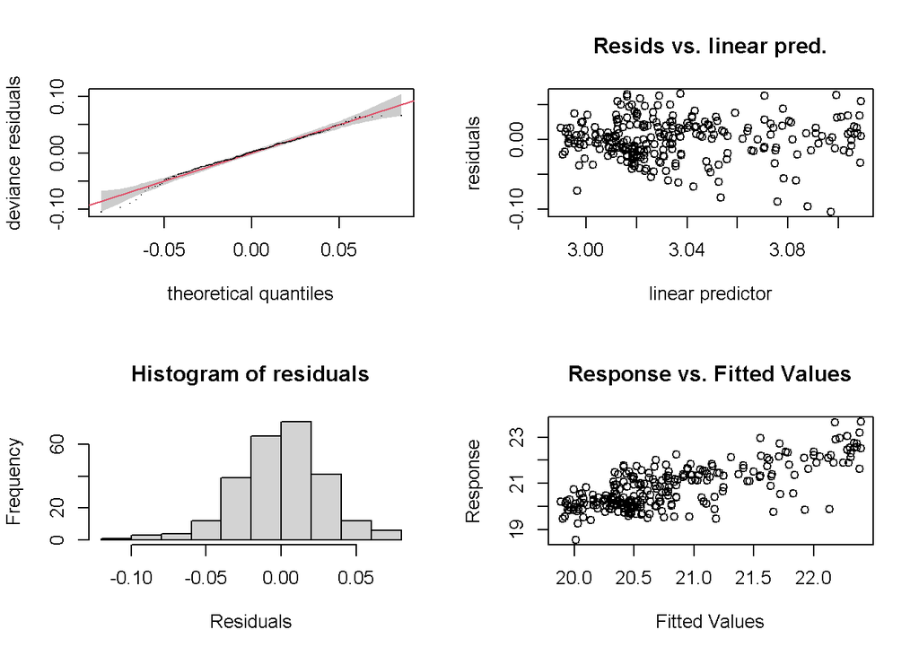

```
##
## Method: REML   Optimizer: outer newton
## full convergence after 6 iterations.
## Gradient range [-0.0000001547716,0.00000001863494]
## (score 257.2124 & scale 0.0008773788).
## Hessian positive definite, eigenvalue range [1.507805,127.5829].
## Model rank =  10 / 10
##
## Basis dimension (k) checking results. Low p-value (k-index<1) may
## indicate that k is too low, especially if edf is close to k'.
##
##           k'  edf k-index p-value
## s(PDRY) 9.00 5.75    0.95    0.18
```

```r
# make function for GAMs
gam_fn <- function(thisformula, thisdata)
{gam(thisformula, family = Gamma(link = "log"), method = "REML", data = thisdata)}

# make function for rounded concurvity (type of colinearity)
# only need for models with > 1 variable
# ranges between 0-1 where 1 is bad, 0 is good
concurvity_fn <- function(model) {
  round(concurvity(model),2)
}

# potential models
# rep gives confidence band on first plot
gam_pdry <- gam_fn(ED ~ s(PDRY), cal_all)
gam.check(gam_pdry, rep = 500)
```

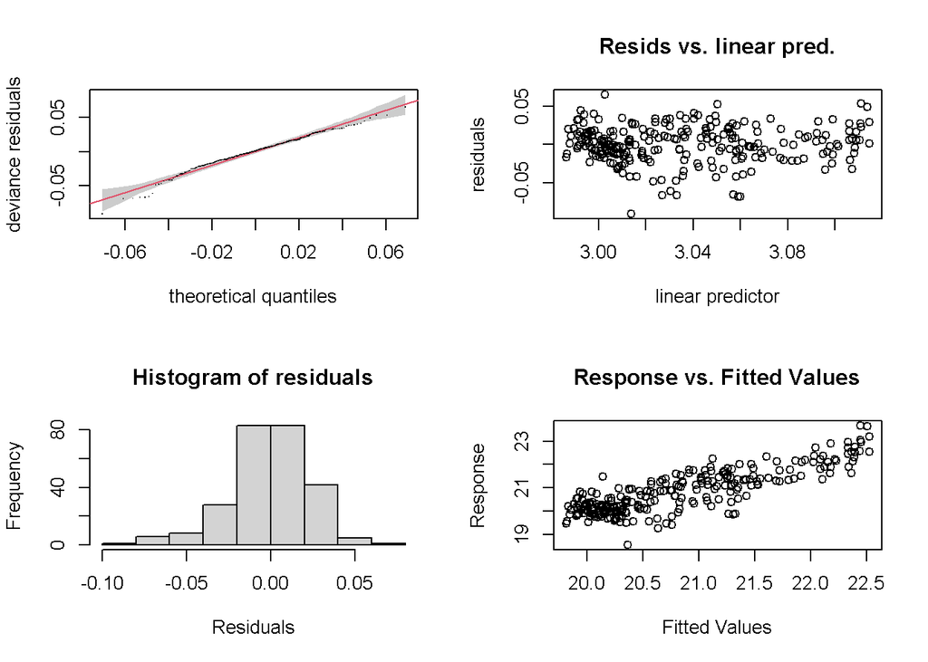

```
##
## Method: REML   Optimizer: outer newton
## full convergence after 6 iterations.
## Gradient range [-0.000001517194,0.0000002933535]
## (score 210.5052 & scale 0.0005751959).
## Hessian positive definite, eigenvalue range [0.4863192,127.0748].
## Model rank =  19 / 19
##
## Basis dimension (k) checking results. Low p-value (k-index<1) may
## indicate that k is too low, especially if edf is close to k'.
##
##           k'  edf k-index p-value
## s(PDRY) 9.00 4.32    0.99    0.44
## s(FORK) 9.00 4.76    1.11    0.95
```

```r
gam_pdry_fl <- gam_fn(ED ~ s(PDRY) + s(FORK), cal_all)
gam.check(gam_pdry_fl, rep = 500)
```

```r
concurvity_fn(gam_pdry_fl)
```

```
##          para s(PDRY) s(FORK)
## worst       0    0.51    0.51
## observed    0    0.43    0.37
## estimate    0    0.29    0.26
```

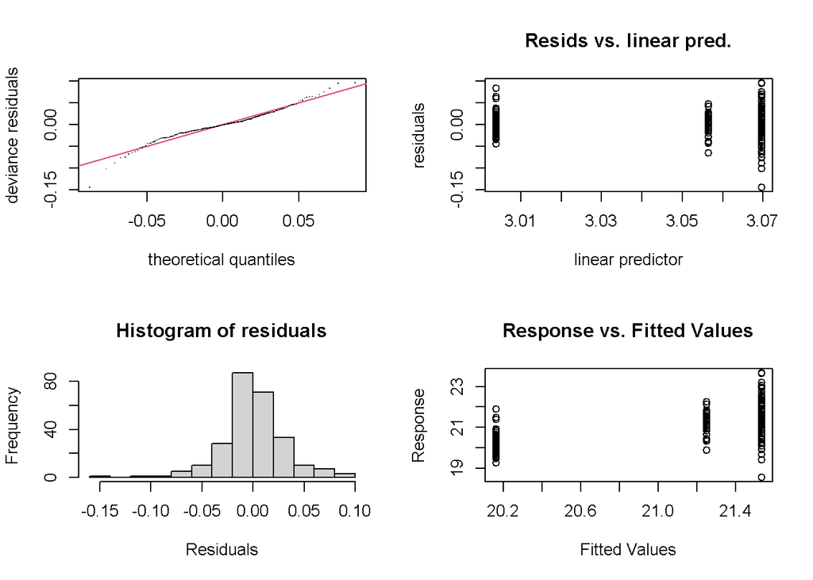

```
##
## Method: REML   Optimizer: outer newton
## full convergence after 5 iterations.
## Gradient range [-0.000009041019,-0.000009041019]
## (score 259.6744 & scale 0.0009189526).
## Hessian positive definite, eigenvalue range [127.0396,127.0396].
## Model rank =  3 / 3
```

```r
gam_season <- gam_fn(ED ~ SEASON, cal_all)
gam.check(gam_season)
```

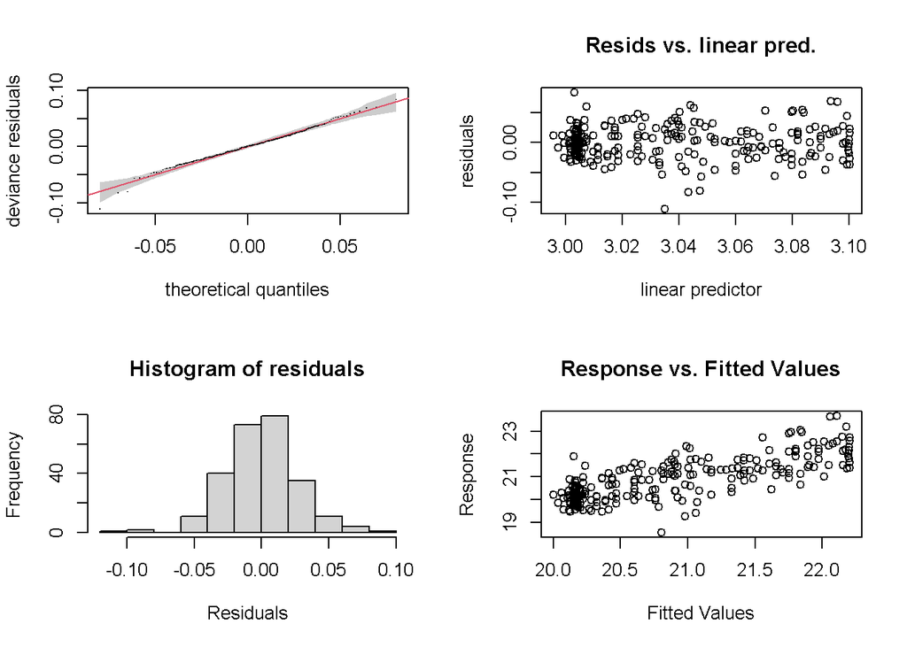

```
##
## Method: REML   Optimizer: outer newton
## full convergence after 6 iterations.
## Gradient range [-0.00000006948022,-0.000000004281925]
## (score 240.1514 & scale 0.0007561931).
## Hessian positive definite, eigenvalue range [1.723638,127.5999].
## Model rank =  10 / 10
##
## Basis dimension (k) checking results. Low p-value (k-index<1) may
## indicate that k is too low, especially if edf is close to k'.
##
##           k'  edf k-index p-value
## s(FORK) 9.00 6.82     1.1    0.94
```

```r
gam_fl <- gam_fn(ED ~ s(FORK), cal_all)
gam.check(gam_fl, rep = 500) # 0.94
```

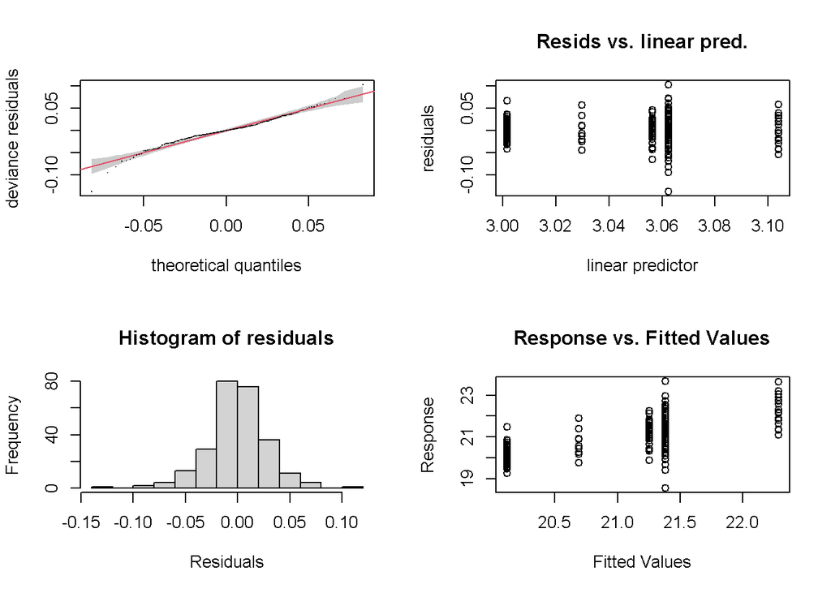

```
##
## Method: REML   Optimizer: outer newton
## full convergence after 5 iterations.
## Gradient range [-0.000001348374,-0.000001348374]
## (score 249.7514 & scale 0.0008049919).
## Hessian positive definite, eigenvalue range [126.0347,126.0347].
## Model rank =  5 / 5
```

```r
gam_month <- gam_fn(ED ~ MONTH, cal_all)
gam.check(gam_month, rep = 500)
```

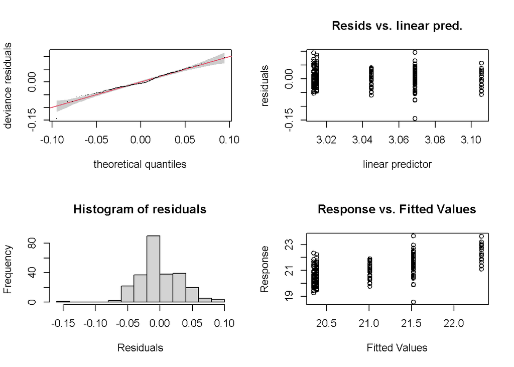

```
##
## Method: REML   Optimizer: outer newton
## full convergence after 5 iterations.
## Gradient range [-0.00004596522,-0.00004596522]
## (score 282.7983 & scale 0.00105168).
## Hessian positive definite, eigenvalue range [126.045,126.045].
## Model rank =  5 / 5
```

```r
gam_catch <- gam_fn(ED ~ CATCH, cal_all)
gam.check(gam_catch, rep = 500)
```

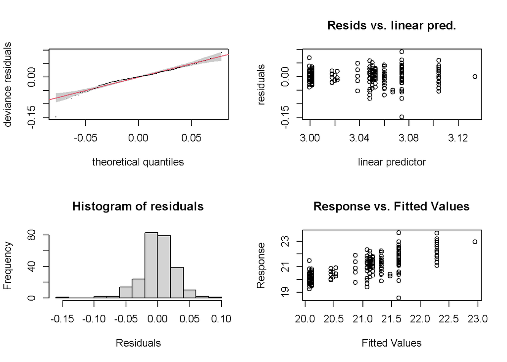

```
##
## Method: REML   Optimizer: outer newton
## full convergence after 5 iterations.
## Gradient range [-0.0000003421718,-0.0000003421718]
## (score 252.6969 & scale 0.0007353434).
## Hessian positive definite, eigenvalue range [124.0319,124.0319].
## Model rank =  9 / 9
```

```r
gam_catch_month <- gam_fn(ED ~ CATCH + MONTH, cal_all)
gam.check(gam_catch_month, rep = 500)
```

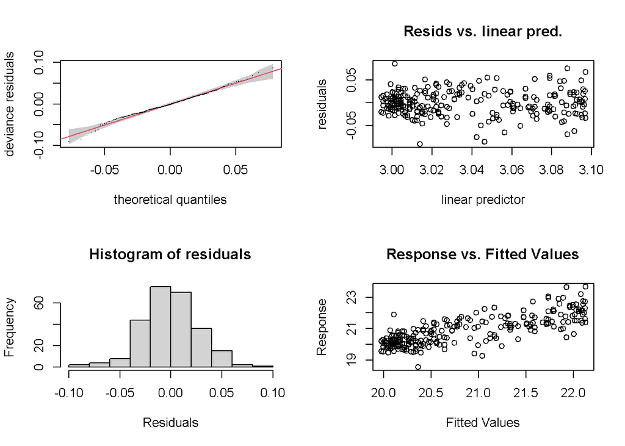

```
##
## Method: REML   Optimizer: outer newton
## full convergence after 6 iterations.
## Gradient range [-0.00000005361422,0.00000004648635]
## (score 231.3485 & scale 0.0007293847).
## Hessian positive definite, eigenvalue range [1.11244,127.5597].
## Model rank =  10 / 10
##
## Basis dimension (k) checking results. Low p-value (k-index<1) may
## indicate that k is too low, especially if edf is close to k'.
##
##          k'  edf k-index p-value
## s(WGT) 9.00 4.79    1.08     0.9
```

```r
gam_wgt <- gam_fn(ED ~ s(WGT), cal_all)
gam.check(gam_wgt, rep = 500)
```

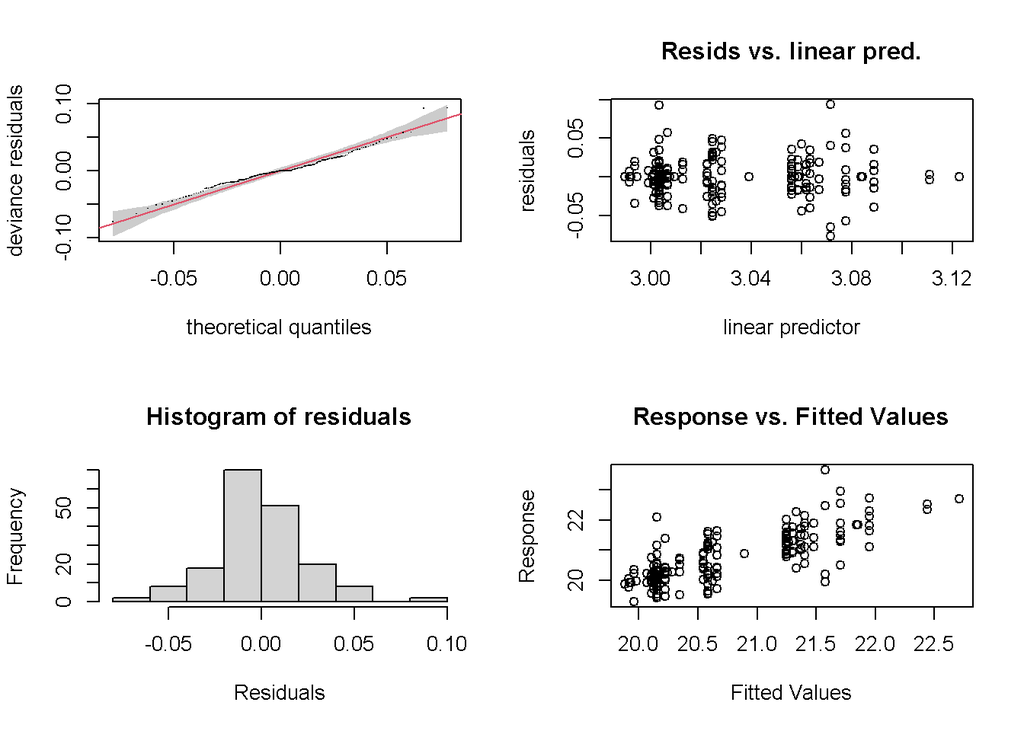

```
##
## Method: REML   Optimizer: outer newton
## full convergence after 5 iterations.
## Gradient range [-0.000006253544,-0.000006253544]
## (score 255.8036 & scale 0.0007913575).
## Hessian positive definite, eigenvalue range [71.02346,71.02346].
## Model rank =  37 / 37
```

```r
# models with GSI training data only
# reduced data set
gam_stk <- gam_fn(ED ~ STOCK, cal_all_gsi)
gam.check(gam_stk, rep = 500)
```

```r
##################################################
# rejected models (high concurvity)
##################################################
#gam_pdry_wgt <- gam_fn(ED ~ s(PDRY) + s(WGT), cal_all)
#gam.check(gam_pdry_wgt, rep = 500)
#concurvity_fn(gam_pdry_wgt)
#
#gam_fl_wgt_interact <- gam_fn(ED ~ te(FORK, WGT), cal_all)
#gam.check(gam_fl_wgt_interact, rep = 500)
#concurvity_fn(gam_fl_wgt_interact)
#
# gam_season_fl <- gam_fn(ED ~ SEASON + s(FORK), cal_all)
# gam.check(gam_season_fl, rep = 500)
# concurvity_fn(gam_season_fl) # concurvity

# gam_season_wgt <- gam_fn(ED ~ SEASON + s(WGT), cal_all)
# gam.check(gam_season_wgt, rep = 500)
# concurvity_fn(gam_season_wgt) # concurvity

# gam_pdry_season <- gam_fn(ED ~ s(PDRY) + SEASON, cal_all)
# gam.check(gam_pdry_season, rep = 500)
# concurvity_fn(gam_pdry_season) #concurvity with season

# gam_pdry_season_interact <- gam_fn(ED ~ SEASON + s(PDRY, by = SEASON), cal_all)
# gam.check(gam_pdry_season_interact, rep = 500)
# concurvity_fn(gam_pdry_season_interact) # concurvity

# gam_pdry_fl_lat <- gam_fn(ED ~ s(PDRY) + s(FORK) + LAT, cal_all)
# gam.check(gam_pdry_fl_lat, rep = 500) # OK
# concurvity_fn(gam_pdry_fl_lat) # 0.29-1 concurvity issues with latitude

# gam_pdry_fl_interact <- gam_fn(ED ~ te(PDRY, FORK), cal_all)
# gam.check(gam_pdry_fl_interact, rep = 500) # 0.34
# concurvity_fn(gam_pdry_fl_interact)
# concurvity(gam_pdry_fl_interact, full = FALSE)# 0 look further

# # decompose interaction
# gam_pdry_fl_interact2 <- gam_fn(ED ~ ti(PDRY) + ti(FORK) + ti(PDRY, FORK),  cal_all)
# gam.check(gam_pdry_fl_interact2, rep = 500) # 0.41-0.98
# summary(gam_pdry_fl_interact2) # significance of interaction term
# concurvity(gam_pdry_fl_interact2, full = TRUE) # concurvity
#
# # check if models with and without interaction are different from each other
# anova.gam(gam_pdry_fl, gam_pdry_fl_interact) # not diff

# gam_pdry_fl_interact_lat <- gam_fn(ED ~ te(PDRY, FORK, k = c(12, 12)) + LAT, cal_all)
# gam.check(gam_pdry_fl_interact_lat, rep = 500) # 0.82
# concurvity_fn(gam_pdry_fl_interact_lat) # concurvity with latitude

# gam_pdry_month <- gam_fn(ED ~ MONTH + s(PDRY), cal_all)
# gam.check(gam_pdry_month, rep = 500)
# concurvity_fn(gam_pdry_month) # concurvity with month

# gam_pdry_month_interact <- gam_fn(ED ~ MONTH + s(PDRY, by = MONTH), cal_all)
# gam.check(gam_pdry_month_interact, rep = 500) # 0.49
# concurvity_fn(gam_pdry_month_interact) # concurvity with month

# # a different way to penalize model for differences by factor
# #https://stats.stackexchange.com/questions/403772/different-ways-of-modelling-interactions-between-continuous-and-categorical-pred
# gam_pdry2_month_interact <- gam_fn(ED ~ MONTH + s(PDRY) + s(PDRY, by = MONTH), cal_all)
# gam.check(gam_pdry2_month_interact)
# concurvity_fn(gam_pdry2_month_interact) # concurvity with month and pdry
# summary(gam_pdry2_month_interact)
# AIC(gam_pdry2_month_interact)

# gam_pdry3_month_interact <- gam_fn(ED ~ MONTH + s(PDRY) + s(PDRY, by = MONTH, m= 1), cal_all)
# gam.check(gam_pdry3_month_interact)
# concurvity_fn(gam_pdry3_month_interact) # concurvity
# summary(gam_pdry3_month_interact)
# AIC(gam_pdry3_month_interact)

# gam_fl_month <- gam_fn(ED ~ MONTH + s(FORK), cal_all)
# gam.check(gam_fl_month)
# concurvity_fn(gam_fl_month) # concurvity with month

# gam_fl_month_interact <- gam_fn(ED ~ MONTH + s(FORK, by = MONTH), cal_all)
# gam.check(gam_fl_month_interact)
# concurvity_fn(gam_fl_month_interact) # concurvity with month

# gam_pdry_fl_month_interact <- gam_fn(ED ~ MONTH + te(PDRY, FORK, by = MONTH, k = 12), cal_all)
# gam.check(gam_pdry_fl_month_interact) # adjusted k up to 12
# concurvity_fn(gam_pdry_fl_month_interact) # concurvity in month
# # note that this is different from t2(PDRY, FORK, by = MONTH)
# # and different from s(PDRY, by = MONTH) + s(FORK, by = MONTH)

## latitude in models
# gam_lat_month <- gam_fn(ED ~ MONTH + s(LAT, k= 55), cal_all)
# gam.check(gam_lat_month) # need > k but data doesn't support more
# concurvity_fn(gam_lat_month) # issues with month

# gam_lat_month_interact <- gam_fn(ED ~ MONTH + s(LAT, by = MONTH, k = 50), cal_all)
# gam.check(gam_lat_month_interact) # need > k but data doesn't support it
# concurvity_fn(gam_lat_month_interact) # concurvity with month

# gam_pdry_fl_interact_month <- gam_fn(ED ~ MONTH + te(PDRY, FORK, k = c(5, 5)), cal_all)
# gam.check(gam_pdry_fl_interact_month)
# concurvity_fn(gam_pdry_fl_interact_month) # concurvity with month

# gam_pdry_catch_interact <- gam_fn(ED ~ CATCH + s(PDRY, by = CATCH), cal_all)
# gam.check(gam_pdry_catch_interact, rep = 500)
# concurvity_fn(gam_pdry_catch_interact) # concurvity with catch region

# gam_pdry_fl_catch_interact <- gam_fn(ED ~ CATCH + te(PDRY, FORK, by = CATCH), cal_all)
# gam.check(gam_pdry_fl_catch_interact, rep = 500)
# concurvity_fn(gam_pdry_fl_catch_interact) # concurvity with catch

# gam_pdry_catch_month_interact <- gam_fn(ED ~ CATCH + MONTH + s(PDRY, by = CATCH) + s(PDRY, by = MONTH), cal_all)
# gam.check(gam_pdry_catch_month_interact) # 0.96-0.96
# concurvity_fn(gam_pdry_catch_month_interact) # concurvity

# gam_fl_catch <- gam_fn(ED ~ CATCH + s(FORK), cal_all)
# gam.check(gam_fl_catch)
# concurvity_fn(gam_fl_catch) # concurvity

# gam_fl_catch_interact <- gam_fn(ED ~ CATCH + s(FORK, by = CATCH), cal_all)
# gam.check(gam_fl_catch_interact) # 0.90-0.93
# concurvity_fn(gam_fl_catch_interact) # concurvity

# gam_fl_catch_month_interact <- gam_fn(ED ~ CATCH + MONTH + s(FORK, by = CATCH) + s(FORK, by = MONTH), cal_all)
# gam.check(gam_fl_catch_month_interact)
# concurvity_fn(gam_fl_catch_month_interact) # concurvity

# gam_pdry_wgt_interact <- gam_fn(ED ~ te(PDRY, WGT, k = c(11, 11)), cal_all)
# gam.check(gam_pdry_wgt_interact, rep = 500)
# concurvity_fn(gam_pdry_wgt_interact) # concurvity when increase knots

# # decompose for colinearity and interaction
# gam_pdry_wgt_interact2 <- gam_fn(ED ~ s(PDRY) + s(WGT) + ti(PDRY, WGT, k = c(11, 11)), cal_all)
# gam.check(gam_pdry_wgt_interact2, rep = 500)
# concurvity_fn(gam_pdry_wgt_interact2) # concurvity

# # check if models with and without interaction are different from each other
# anova.gam(gam_pdry_wgt, gam_pdry_wgt_interact) # not diff

# gam_pdry_wgt_catch_interact <- gam_fn(ED ~ CATCH + te(PDRY, WGT, by = CATCH), cal_all)
# gam.check(gam_pdry_wgt_catch_interact)
# concurvity_fn(gam_pdry_wgt_catch_interact) #concurvity

# gam_wgt_fl_catch_interact <- gam_fn(ED ~ CATCH + te(WGT, FORK, by = CATCH), cal_all)
# gam.check(gam_wgt_fl_catch_interact)
# concurvity_fn(gam_wgt_fl_catch_interact) # concurvity

# gam_pdry_wgt_month_interact <- gam_fn(ED ~ MONTH + te(PDRY, WGT, by = MONTH, k = c(15, 15)), cal_all)
# gam.check(gam_pdry_wgt_month_interact, rep = 500)
# concurvity_fn(gam_pdry_wgt_month_interact) # concurvity

# gam_wgt_month_interact <- gam_fn(ED ~ MONTH + s(WGT, by = MONTH), cal_all)
# gam.check(gam_wgt_month_interact, rep = 500)
# concurvity_fn(gam_wgt_month_interact) # concurvity

# gam_wgt_catch_interact <- gam_fn(ED ~ CATCH + s(WGT, by = CATCH), cal_all)
# gam.check(gam_wgt_catch_interact, rep = 500)
# concurvity_fn(gam_wgt_catch_interact) # concurvity

# gam_wgt_month_interact <- gam_fn(ED ~ MONTH + s(WGT, by = MONTH), cal_all)
# gam.check(gam_wgt_month_interact, rep = 500)
# concurvity_fn(gam_wgt_month_interact) # concurvity

# gam_fl_wgt <- gam_fn(ED ~ s(FORK) + s(WGT), cal_all)
# gam.check(gam_fl_wgt, rep = 500)
# concurvity_fn(gam_fl_wgt) # concurvity

# gam_stk_yd <- gam_fn(ED ~ STOCK + s(YDAY2), cal_all_gsi)
# gam.check(gam_stk_yd)
# concurvity_fn(gam_stk_yd) # concurvity

# gam_stk_pdry <- gam_fn(ED ~ s(PDRY) + STOCK,  cal_all_gsi)
# gam.check(gam_stk_pdry)
# concurvity_fn(gam_stk_pdry) # concurvity

##################################################

# make list of potential models to evaluate
modelList <- list(gam_catch = gam_catch,
                  gam_catch_month = gam_catch_month,
                  gam_fl = gam_fl,
                  gam_month = gam_month,
                  gam_pdry = gam_pdry,
                  gam_pdry_fl = gam_pdry_fl,
                  gam_season = gam_season,
                  gam_stk = gam_stk,
                  gam_wgt = gam_wgt)

# use data frame with list columns to hold all models together
modelDf_orig <- tibble(thismodel = modelList)

# create function to get model formula from model in list column
getFormula_fn <- function(x) {
  deparse(x$formula)
}

# model to get deviance explained from all models
getDevianceExplained_fn <- function(x) {
  summary(x)$dev.expl
}

# add AIC to compare models
modelDf <- modelDf_orig %>%
  mutate(thisname = names(thismodel),
         thisAIC = round(map_dbl(thismodel, AIC), 2),
         thisdeviance = round(map_dbl(thismodel, getDevianceExplained_fn)*100,2),
         updateName = str_replace_all(thisname, "gam_", ""),
         thisformula = map_chr(thismodel, getFormula_fn)) %>%
  arrange(-thisdeviance) %>%
  dplyr::select(updateName,thisformula, thisAIC, thisdeviance)

# save as csv info for table 2
write_csv(modelDf, here::here(OutputFolder, "/modelTable.csv"), na = "")

# explore model results
BestModels <- list(gam_pdry_fl,
                   gam_wgt)

# look at model summaries
map(BestModels, summary)
```

```
## [[1]]
##
## Family: Gamma
## Link function: log
##
## Formula:
## ED ~ s(PDRY) + s(FORK)
##
## Parametric coefficients:
##             Estimate Std. Error t value            Pr(>|t|)
## (Intercept) 3.035702   0.001496    2029 <0.0000000000000002 ***
## ---
## Signif. codes:  0 '***' 0.001 '**' 0.01 '*' 0.05 '.' 0.1 ' ' 1
##
## Approximate significance of smooth terms:
##           edf Ref.df     F             p-value
## s(PDRY) 4.318  5.382 17.87 <0.0000000000000002 ***
## s(FORK) 4.762  5.866 25.06 <0.0000000000000002 ***
## ---
## Signif. codes:  0 '***' 0.001 '**' 0.01 '*' 0.05 '.' 0.1 ' ' 1
##
## R-sq.(adj) =  0.699   Deviance explained = 70.5%
## -REML = 210.51  Scale est. = 0.0005752  n = 257
##
## [[2]]
##
## Family: Gamma
## Link function: log
##
## Formula:
## ED ~ s(WGT)
##
## Parametric coefficients:
##             Estimate Std. Error t value            Pr(>|t|)
## (Intercept) 3.035780   0.001685    1802 <0.0000000000000002 ***
## ---
## Signif. codes:  0 '***' 0.001 '**' 0.01 '*' 0.05 '.' 0.1 ' ' 1
##
## Approximate significance of smooth terms:
##          edf Ref.df     F             p-value
## s(WGT) 4.787  5.846 69.56 <0.0000000000000002 ***
## ---
## Signif. codes:  0 '***' 0.001 '**' 0.01 '*' 0.05 '.' 0.1 ' ' 1
##
## R-sq.(adj) =  0.613   Deviance explained = 62.2%
## -REML = 231.35  Scale est. = 0.00072938  n = 257
```

```r
# define models to use
bestmodel1 <- gam_pdry_fl
bestmodel2 <- gam_wgt

# variables for model names in text
bestmodel1name <- "pdry_fl"
bestmodel2name <- "wgt"

# save models
saveRDS(bestmodel1, here::here(str_c(OutputFolder,
                                     "/bestmodel1.rds")))
saveRDS(bestmodel2, here::here(str_c(OutputFolder,
                                      "/bestmodel2.rds")))
saveRDS(gam_stk,  here::here(str_c(OutputFolder,
                                   "/gam_stk.rds")))

write_csv(modelDf, here::here(str_c(OutputFolder,
                                    "/modelDf.csv")))

###################################################

# get vector of stocks that can use stock model
cal_stocks_vec <- cal_all_gsi %>%
  select(STOCK) %>%
  distinct() %>%
  pull(STOCK)

# estimate ED with top models, including stock
dry_gsi_mod <- dry_gsi %>%
  filter(STOCK %in% cal_stocks_vec) %>%
  spread_predictions(gam_stk, type = "response") %>%
  right_join(., dry_gsi, by = c("CRUISE", "DATE", "FISH_NUMBER", "FORK", "WGT", "LAT", "LONG", "YEAR", "SEASON", "PDRY", "YDAY1", "ED", "METHOD", "SPECIES", "STOCK_FINAL", "PROB_1", "HS_REGION", "CU_ACRO", "SOURCE", "YDAY2", "MONTH", "STOCK", "ORIGIN", "CATCH")) %>%
  spread_predictions(bestmodel1,
                     bestmodel2,
                     type = "response") %>%
  mutate(ED_1 = if_else(is.na(ED), bestmodel1, ED),
         ED_2 = if_else(is.na(ED), bestmodel2, ED),
         ED_stk = if_else(is.na(ED), gam_stk, ED))
```

## Tables

### Models

Table 1. Generalized additive models for juvenile sockeye salmon energy density, Akaike information criterion (AIC), ordered by decreasing percent deviance explained. All models used a gamma distribution with a log link function, the restricted maximum likelihood (REML) method, and basis functions were checked. Abbreviations: ED = energy density, PDRY = percent dry weight, FORK = fork length, WGT = wet weight, CATCH = catch region, MONTH = month caught.

```r
# display model table
kable(modelDf,
      col.names = c("Name", "Model", "AIC", "Deviance Explained")) %>%
  kable_styling()
```

| Name | Model | AIC | Deviance Explained |
| --- | --- | --- | --- |
| pdry_fl | ED ~ s(PDRY) + s(FORK) | 390.68 | 70.51 |
| wgt | ED ~ s(WGT) | 442.27 | 62.24 |
| catch_month | ED ~ CATCH + MONTH | 449.66 | 61.94 |
| fl | ED ~ s(FORK) | 454.14 | 61.12 |
| stk | ED ~ STOCK | 352.35 | 60.60 |
| month | ED ~ MONTH | 467.27 | 57.94 |
| pdry | ED ~ s(PDRY) | 492.56 | 54.44 |
| season | ED ~ SEASON | 498.87 | 51.68 |
| catch | ED ~ CATCH | 533.62 | 45.55 |

### Origins

```r
# number of stocks in training dataset
stocksintraining <- length(unique(cal_all_gsi$STOCK))
stocksintraining
```

```
## [1] 37
```

```r
# number of stocks in full dataset
stockinlargedataset <- length(unique(dry_gsi$STOCK))
stockinlargedataset
```

```
## [1] 88
```

```r
# number of modeled results in full data
ndry_gsi_mod <- nrow(dry_gsi_mod)
ndry_gsi_mod
```

```
## [1] 2019
```

```r
# group stocks by high sea region
reg_full <- dry_gsi_mod %>%
  mutate(HS_REGION = str_replace_all(HS_REGION, "RIVERS & SMITH INLET", "BC CENTRAL COAST")) %>%
  group_by(HS_REGION) %>%
  summarise(nFull = length(FISH_NUMBER),
            perFull = round(nFull/ndry_gsi_mod * 100, 0),
            .groups = "drop") %>%
  arrange(-perFull)

# do same for training data set to compare
ncal_all_gsi <- nrow(cal_all_gsi)

reg_train <- cal_all_gsi %>%
  mutate(HS_REGION = str_replace_all(HS_REGION, "RIVERS & SMITH INLET", "BC CENTRAL COAST")) %>%
  group_by(HS_REGION) %>%
  summarise(nTrain = length(FISH_NUMBER),
            perTrain = round(nTrain/ncal_all_gsi * 100, 0),
            .groups = "drop") %>%
  arrange(-perTrain)

# put together
reg <- reg_train %>%
  right_join(., reg_full, by = "HS_REGION") %>%
  mutate(perTrainFull = round(nTrain/nFull * 100, 0),
         HS_REGION = str_to_title(HS_REGION),
         HS_REGION = gsub("Bc", "BC", HS_REGION),
         HS_REGION = gsub("Wcvi", "WCVI", HS_REGION),
         HS_REGION = gsub("Ecvi", "ECVI", HS_REGION),
         HS_REGION = gsub("Seak", "SEAK", HS_REGION)) %>%
  select(-perTrainFull) %>%
  replace_na(list(nTrain = 0, perTrain = 0))

# variables for text
fraserperTrain <- reg %>%
  filter(HS_REGION == "Fraser") %>%
  pull(perTrain)
fraserperTrain
```

```
## [1] 59
```

```r
fraserperFull <- reg %>%
  filter(HS_REGION == "Fraser") %>%
  pull(perFull)
fraserperFull
```

```
## [1] 47
```

```r
# write as csv
write_csv(reg, here::here(OutputFolder, "/regions.csv"), na = "-")
```

```r
# display region table
kable(reg,
      col.names = c("Region of Origin", "n training", "% training", "n full", "% full")) %>%
  kable_styling()
```

| Region of Origin | n training | % training | n full | % full |
| --- | --- | --- | --- | --- |
| Fraser | 105 | 59 | 939 | 47 |
| ECVI | 32 | 18 | 88 | 4 |
| WCVI | 17 | 9 | 303 | 15 |
| BC Central Coast | 14 | 8 | 278 | 14 |
| BC North Coast | 7 | 4 | 347 | 17 |
| BC South Coast | 1 | 1 | 7 | 0 |
| Puget Sound | 2 | 1 | 28 | 1 |
| SEAK | 1 | 1 | 10 | 0 |
| Columbia | 0 | 0 | 19 | 1 |

### Comparison

```r
# function for standard error of the mean
sem_fn <- function(x) {

  sd(x, na.rm = TRUE)/sqrt(length(x[!is.na(x)]))
}

# function to get totals for best model
EDbyStockfn <- function(df, season) {

  if (season == "all") {df2 <- df}
  if (season == "summer") {df2 <- df %>% filter(MONTH %in% c(6,7,8))}
  if (season == "fall") {df2 <- df %>% filter(MONTH %in% c(9,10,11))}

df2  %>%
  mutate(HS_REGION = str_to_title(HS_REGION),
         HS_REGION = str_replace_all(HS_REGION, "Bc", "BC"),
         HS_REGION = str_replace_all(HS_REGION, "Wcvi", "WCVI"),
         HS_REGION = str_replace_all(HS_REGION, "Ecvi", "ECVI"),
         HS_REGION = str_replace_all(HS_REGION, "Seak", "SEAK")) %>%
  dplyr::rename(Stock = STOCK) %>%
group_by(Stock, ORIGIN, HS_REGION) %>%
  summarise( n = length(FISH_NUMBER),
             mean = round(mean(ED_1 , na.rm = TRUE), 2),
             min = round(min(ED_1 , na.rm = TRUE),2),
             max = round(max(ED_1 , na.rm = TRUE),2),
             se = round(sem_fn(ED_1), 2),
             sd = round(sd(ED_1), 2),
             .groups = "drop") %>%
  arrange(-mean)

  }

stockED_bestmodel1 <- EDbyStockfn(dry_gsi_mod, "all")
stockED_bestmodel1_summer <- EDbyStockfn(dry_gsi_mod, "summer")
stockED_bestmodel1_fall <- EDbyStockfn(dry_gsi_mod, "fall")

# get totals for stock model
stockED_stk  <- dry_gsi_mod  %>%
  mutate(HS_REGION = str_to_title(HS_REGION),
         HS_REGION = str_replace_all(HS_REGION, "Bc", "BC"),
         HS_REGION = str_replace_all(HS_REGION, "Wcvi", "WCVI"),
         HS_REGION = str_replace_all(HS_REGION, "Ecvi", "ECVI"),
         HS_REGION = str_replace_all(HS_REGION, "Seak", "SEAK")) %>%
  dplyr::rename(Stock = STOCK) %>%
  filter(!(is.na(ED_stk))) %>%
  group_by(Stock, ORIGIN, HS_REGION) %>%
  summarise( n = length(FISH_NUMBER),
             mean = round(mean(ED_stk, na.rm = TRUE), 2),
             min = round(min(ED_stk , na.rm = TRUE),2),
             max = round(max(ED_stk , na.rm = TRUE),2),
             se = round(sem_fn(ED_stk), 2),
             sd = round(sd(ED_stk), 2),
             .groups = "drop") %>%
  arrange(-mean)

# create a function to total using different models
# find totals, min and max, se and sd
get_totals_fn <- function(model, colName, df) {

  myenc <- enquo(colName)

  if (model == "stock") {
    df %>%
      filter(!is.na(!!myenc)) %>%
      summarise(model = model,
                n = length(FISH_NUMBER),
                mean = round(mean(!!myenc, na.rm = TRUE), 2),
                min = round(min(!!myenc, na.rm = TRUE),2),
                max = round(max(!!myenc, na.rm = TRUE),2),
                se = round(sem_fn(!!myenc), 2),
                sd = round(sd(!!myenc, na.rm = TRUE), 2))


  } else {

    df %>%
      summarise(model = model,
                n = length(FISH_NUMBER),
                mean = round(mean(!!myenc, na.rm = TRUE), 2),
                min = round(min(!!myenc, na.rm = TRUE),2),
                max = round(max(!!myenc, na.rm = TRUE),2),
                se = round(sem_fn(!!myenc), 2),
                sd = round(sd(!!myenc, na.rm = TRUE), 2))
  }
}

#apply to select models to compare
Totals_measured <- get_totals_fn("measured", ED , cal_all)
Totals_bestmodel1 <- get_totals_fn(bestmodel1name, bestmodel1, dry_gsi_mod)
Totals_bestmodel2 <- get_totals_fn(bestmodel2name, bestmodel2 , dry_gsi_mod)
Totals_stock <- get_totals_fn("stock", gam_stk, dry_gsi_mod)

# put models together
Total_ED <- rbind(Totals_measured, Totals_bestmodel1,
                  Totals_bestmodel2, Totals_stock)

# write as csv
write_csv(Total_ED, here::here(OutputFolder, "/EDTotals.csv"),
          na = "")
```

### Birkenhead

A highly variable stock in summer was Birkenhead, within the Lillooet-Harrison L conservation unit. From 2002-2009, this stock was moved to the summer run timing group and in 2012 the status was accessed as green status. In 2010, Birkenhead was moved back into the late run timing group and by 2017 was accessed as amber status (Grant et al 2011, Fisheries and Oceans Canada 2020). It is plausible that the variability with Birkenhead juvenile sockeye salmon represents the variability associated with shifting run timing and decreasing condition. Find pre-2010 energy densities to compare to after 2010.

```r
birk <- dry_gsi_mod %>%
  filter(STOCK == "Birkenhead") %>%
  select(YEAR, ED_1) %>%
  mutate(era = if_else(YEAR < 2010, "summer", "late")) %>%
  group_by(era) %>%
  summarise(n = n(),
    meanED = mean(ED_1))
birk
```

```
## # A tibble: 2 x 3
##   era        n meanED
##   <chr>  <int>  <dbl>
## 1 late      11   20.2
## 2 summer    24   21.2
```

## Figures

### Map

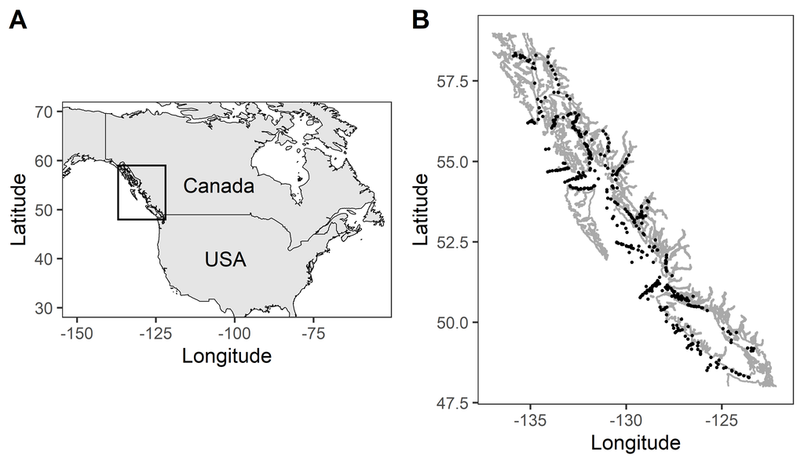

```r
# load shapefile of coast
shapefile <- readOGR(here::here("Input", "Spatial"), "Land", verbose = FALSE)

# convert to a dataframe for use in ggplot2
shapefile_df <- fortify(shapefile)

# get map of north America
nAmerica <- map_data("world") %>%
  filter(region %in% c("Canada", "USA"))

# make map of North America with bounding box
can <- ggplot() +
  geom_map(data = nAmerica, map = nAmerica, aes(map_id = region),
           color = "black", fill = "gray90", size = 0.2) +
  coord_quickmap(xlim = c(-150, -55), ylim = c(30, 70)) +
  # add bounding box showing location of BC map
  geom_rect(aes(xmin = -137, xmax = -122,
                ymax = 48, ymin = 58.3),
            fill = NA, color = "black", size = 0.5) +
  geom_text(aes(-105, 55), label = "Canada") +
  geom_text(aes(-103, 40), label = "USA") +
    labs(x = "Longitude",
         y = "Latitude") +
  theme(panel.grid = element_blank(),
        strip.background = element_rect(fill = "white"))

# Display tow locations on map
  bc <- ggplot(dry_gsi, aes(LONG, LAT)) +
  geom_path(data = shapefile_df,
            aes(long, lat, group = group),
            color = "darkgrey", na.rm = TRUE) +
  geom_point(shape = 16, size = 0.5) +
  coord_quickmap(xlim = c(-137, -122), ylim = c(48, 58.3)) +
    # hide BC - Alberta border
  geom_rect(aes(xmin = -128, xmax = -120,
                ymax = 60, ymin = 55),
            fill = "white", color = "white", size = 0.5) +
  theme(panel.grid = element_blank(),
        strip.background = element_rect(fill = "white")) +
  labs(x = "Longitude",
       y = "Latitude")

  mapstogether <- ggpubr::ggarrange(can, bc, labels = "AUTO")

# save as png
ggsave(here::here(OutputFolder, "/map.png"),
       plot = mapstogether,
       width =  6, height = 3.5,
       dpi = 600)
```

### Boxplot

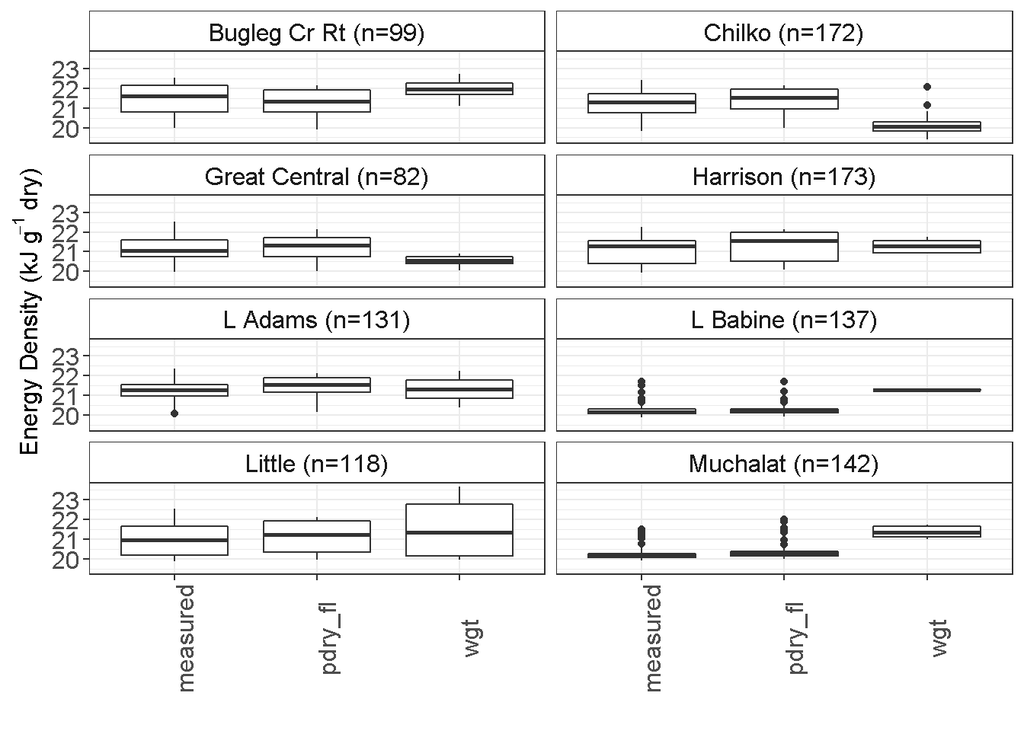

```r
#select most abundant stocks with energy density values
abundantED <- dry_gsi_mod %>%
  group_by(STOCK) %>%
  count() %>%
  ungroup() %>%
  top_n(., 8, n) %>%
  pull(STOCK)

# create data frame to label the number of samples in faceted plot
nAbundant <- dry_gsi_mod %>%
  filter(STOCK %in% abundantED) %>%
  group_by(STOCK) %>%
  count() %>%
  ungroup() %>%
  mutate(nlabel = str_c(STOCK, " (n=", n, ")", sep = ""))

# select data and reorder for graph
ED_compare_models <- dry_gsi_mod %>%
  filter(STOCK %in% abundantED) %>%
  pivot_longer(., cols = c(ED, bestmodel1, bestmodel2,
                           #gam_stk,
                           )) %>%
  dplyr::select(STOCK, name, value) %>%
  left_join(., nAbundant, by = "STOCK") %>%
  filter(!(is.na(value)))

# order the model types for graph
ED_compare_models$name <- as.factor(ED_compare_models$name)
#unique(ED_compare_models$name)
levels(ED_compare_models$name) <- c("ED",
                                    bestmodel1name,
                                    bestmodel2name
                                    #,
                                    #"gam_stock"
                                    )

# graph the comparison
ggplot(ED_compare_models) +
  facet_wrap(~nlabel, ncol = 2) +
  geom_boxplot(aes(name, value)) +
  theme(axis.text.x = element_text(angle = 90),
        strip.background = element_rect(fill = "white")) +
  biggerfontfn() +
  scale_x_discrete(labels = c("measured", bestmodel1name, bestmodel2name
                              #,
                              #"stock"
                              )) +
  labs(y = bquote('Energy Density (kJ g'^-1~'dry)'),
       x = "")
```

```r
# save figure
ggsave(here::here(str_c(OutputFolder, "/modelsBoxplot.png")),
      width =  6, height = 8)
```

Figure 2. Model estimated energy densities are comparable to measured energy densities. The box plots display the median (horizontal line within box), first and third quartiles (box top and bottom), range (vertical lines) and outliers (circles) of measured or estimated energy density from example stocks. Energy density is in kJ g-1 dry weight. Models are defined in Table 1.

### Smoothed Effects

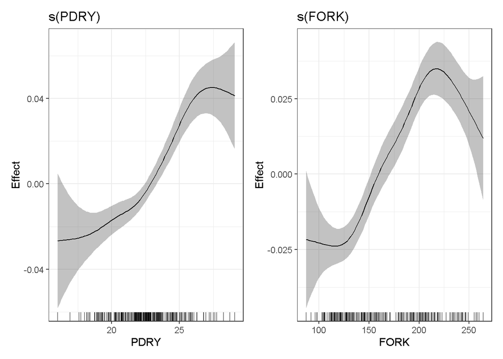

```r
# use gratia to visualize effects
visual_bestmodel1 <- draw(bestmodel1)
visual_bestmodel1
```

```r
ggsave(here::here(str_c(OutputFolder,
                        "/visual_bestmodel1.png")),
       visual_bestmodel1)
```

Figure 3. Smoothed effects of percent dry weight (PDRY) and fork length (FORK) within the GAM called pdry_fl (Table 1). Energy density increased as percent dry weight increases, except at the upper limit of the model. Energy density increased as fork length increased, until approximately 220 mm, when the energy density decreased.

### Seasonal Violin Plot

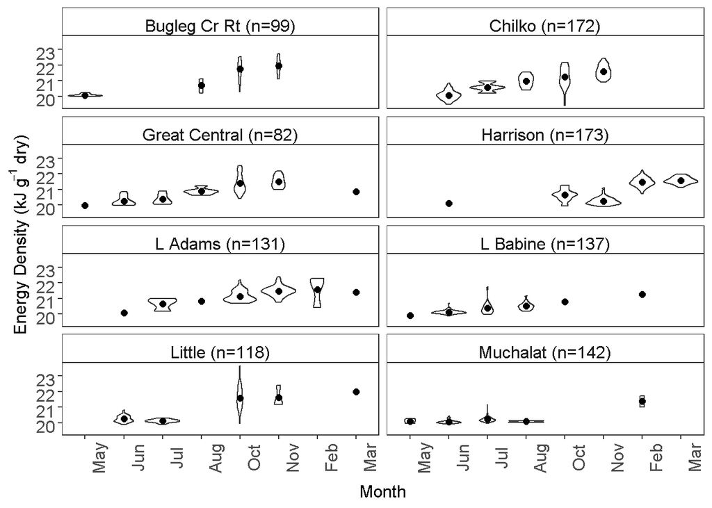

```r
# select abundance stocks from gsi data
dry_gsi_mod %>%
  filter(STOCK %in% abundantED) %>%
  mutate(displayOrder = case_when(
    MONTH == 5 ~ 5,
    MONTH == 6 ~ 6,
    MONTH == 7 ~ 7,
    MONTH == 8 ~ 8,
    MONTH == 9 ~ 9,
    MONTH == 10 ~ 10,
    MONTH == 11 ~ 11,
    MONTH == 12 ~ 12,
    MONTH == 1 ~ 13,
    MONTH == 2 ~ 14,
    MONTH == 3 ~ 15)) %>%
  left_join(., nAbundant, by = "STOCK") %>%

  # omit least abundant stock to fit better on page
  filter(n > 65) %>%
  select(displayOrder, ED_1, nlabel) %>%

  # violin plot
  ggplot(aes(factor(displayOrder), ED_1)) +
  geom_violin()+
  stat_summary(fun = mean, geom = "point", size = 2, color = "black") +
  labs(x = "Month",
       y =   bquote('Energy Density (kJ g'^-1~'dry)')) +
  facet_wrap(~nlabel, ncol = 2, drop = FALSE) +
  theme(panel.grid = element_blank(),
        axis.text.x = element_text(angle = 90),
        strip.background = element_rect(fill = "white")) +
  biggerfontfn() +
  scale_x_discrete(labels = c("May", "Jun", "Jul", "Aug", "Oct", "Nov","Feb", "Mar"))
```

```r
# save plot
ggsave(here::here(OutputFolder, "violin_month_bestmodel1.png"),
       width = 7, height = 9)
```

### Critical Size Hypothesis

```r
# percentage of overwinter samples
overwinter <- dry_gsi_mod %>%
  filter(MONTH %in% c(1:3)) %>%
  group_by(STOCK) %>%
  summarise(numFish = length(FISH_NUMBER),
            perFish = round((numFish/nrow(filter(dry_gsi_mod, MONTH %in% c(1:3))))*100)) %>%
  arrange(-perFish)

# what percentage of overwinter are Harrison?
harrsionPercent <- overwinter %>%
  filter(STOCK == "Harrison") %>%
  pull(perFish)
harrsionPercent
```

```
## [1] 79
```

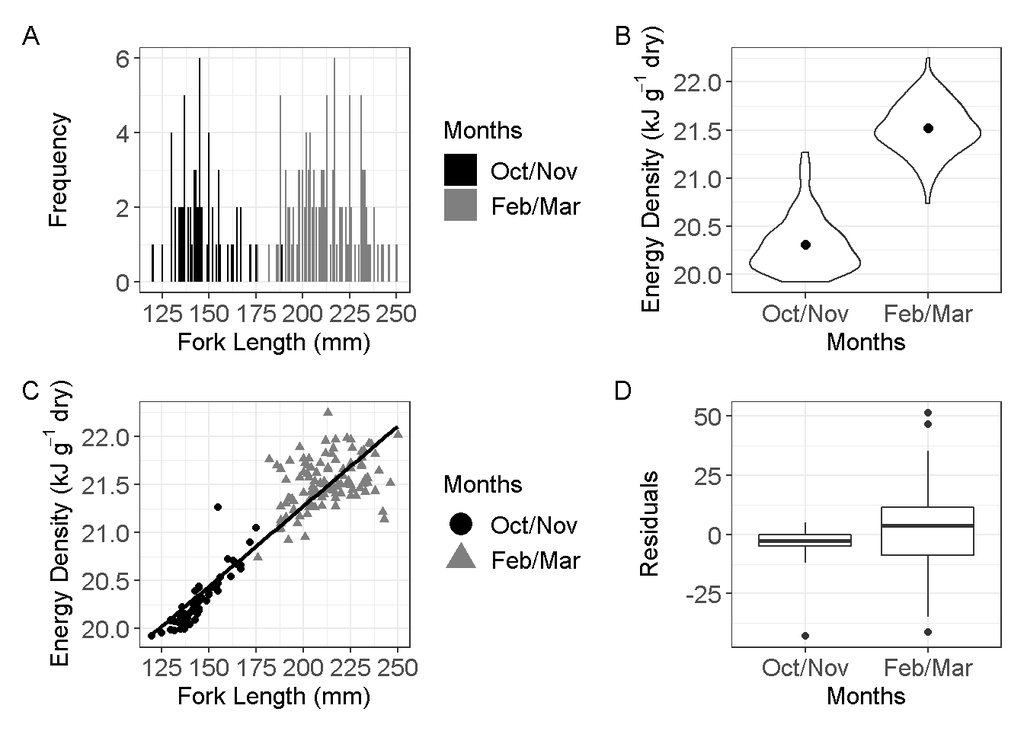

```r
# use Harrison only as majority of over winter samples
criticalDF <- dry_gsi_mod %>%
  filter(STOCK == "Harrison") %>%
  select(FISH_NUMBER, FORK, SEASON, MONTH, ED_1) %>%
  # remove one caught in summer
  filter(SEASON != "Summer") %>%
  mutate(MonthFac = case_when(
    MONTH == 10 | MONTH == 11 ~ "Oct/Nov",
    MONTH == 2 | MONTH == 3 ~ "Feb/Mar"
  ))

# relevel
criticalDF$MonthFac <- factor(criticalDF$MonthFac,
                              levels = c("Oct/Nov", "Feb/Mar"))

# summarize values
criticalDfsum <- criticalDF %>%
  group_by(MonthFac) %>%
  summarise(nFORK = length(FORK),
            meanFORK = round(mean(FORK), 1),
            minFORK = round(min(FORK), 1),
            maxFORK = round(max(FORK), 1),
            varFORK = round(var(FORK),1),
            sdFORK = round(sd(FORK),1),
            nED = length(ED_1),
            meanED = round(mean(ED_1),1),
            minED = round(min(ED_1),1),
            maxED = round(max(ED_1),1),
            varED = round(var(ED_1),1))

# length frequency
lengthFreq <- ggplot(criticalDF) +
  geom_bar(aes(FORK, fill = MonthFac)) +
  scale_fill_manual(values = c("black", "gray50")) +
  scale_x_continuous(breaks = c(seq(100, 260, by = 25))) +
  labs(y = "Frequency",
       x = "Fork Length (mm)",
       fill = "Months") +
  biggerfontfn()

edFreq <- ggplot(criticalDF,
                 aes(MonthFac, ED_1)) +
  geom_violin() +
  stat_summary(fun = mean, geom = "point", size = 2, color = "black") +
  labs(x = "Months",
       y = bquote('Energy Density (kJ g'^-1~'dry)')
       ) +
  biggerfontfn()

harrisonlm <- ggplot(criticalDF, aes(FORK, ED_1)) +
    geom_point(aes(
      color = MonthFac,
      shape = MonthFac)) +
  labs(x = "Fork Length (mm)",
       y = bquote('Energy Density (kJ g'^-1~'dry)'),
       color = "Months",
       shape = "Months") +
  geom_smooth(method = "lm", formula = 'y~x', se = FALSE, color = "black") +
  scale_color_manual(values = c("black", "gray50")) +
  guides(color = guide_legend(override.aes = list(size = 5))) +
  scale_y_continuous(breaks = c(seq(20, 22.4, by = 0.5))) +  scale_x_continuous(breaks = c(seq(100, 260, by = 25))) +
  biggerfontfn()

# ED vs FL residuals by model
mod <- lm(FORK ~ ED_1, data = criticalDF)

Harrisonboxplot <- criticalDF %>%
  modelr::add_residuals(mod) %>%

  ggplot(aes(MonthFac, resid, group = MonthFac)) +
    geom_boxplot() +
      labs(x = "Months",
       y = "Residuals") +
  biggerfontfn()

# arrange plots using patchwork
harrisonGraphs <- lengthFreq + edFreq +
  harrisonlm + Harrisonboxplot +
  plot_annotation(tag_levels = 'A')
harrisonGraphs
```

```r
# save as png for word document
ggsave(here::here(OutputFolder, "/harrisonGraphs.png"),
       plot = harrisonGraphs,
       width =  8, height = 6,
       dpi = 600)
```

Figure 5. Harrison juvenile sockeye salmon overwinter in coastal marine environments. (A) Fork length (mm) plotted by frequency in October/November and February/March showed an increase of mean fork length without a decrease in variance that would indicate size-selective mortality. (B) Model estimated energy density in October/November and February/March showed an increase overwinter. (C) There is a positive linear relationship between fork length and energy density overwinter. (D) Residuals from the linear relationship show variance of energy densities increased with fork length over winter.

### Pink Competition

```r
# high sea regions for stocks in Salish Sea
salish <- c("FRASER", "ECVI")

# odd years are dominant for returning Fraser adults in southern BC
# even years have abundant juvenile pinks in southern BC
pkdom <- c(seq(from = 1998, to = 2012, by = 2))

# wrangle data
pkdata <- dry_gsi_mod %>%
  mutate(salish = if_else(toupper(HS_REGION) %in% salish, "Y", "N"),
         pkDom = if_else(YEAR %in% pkdom, "Abundant", "Few")) %>%
  filter(salish == "Y")

# is there a difference?
pkstats_pd <- as_tibble(rcompanion::groupwiseMean(ED_1 ~ pkDom, data = pkdata, conf = 0.95, digits = 3))
pkstats_pd
```

```
## # A tibble: 2 x 6
##   pkDom        n  Mean Conf.level Trad.lower Trad.upper
##   <chr>    <int> <dbl>      <dbl>      <dbl>      <dbl>
## 1 Abundant   621  21.1       0.95       21         21.1
## 2 Few        406  21.2       0.95       21.1       21.2
```

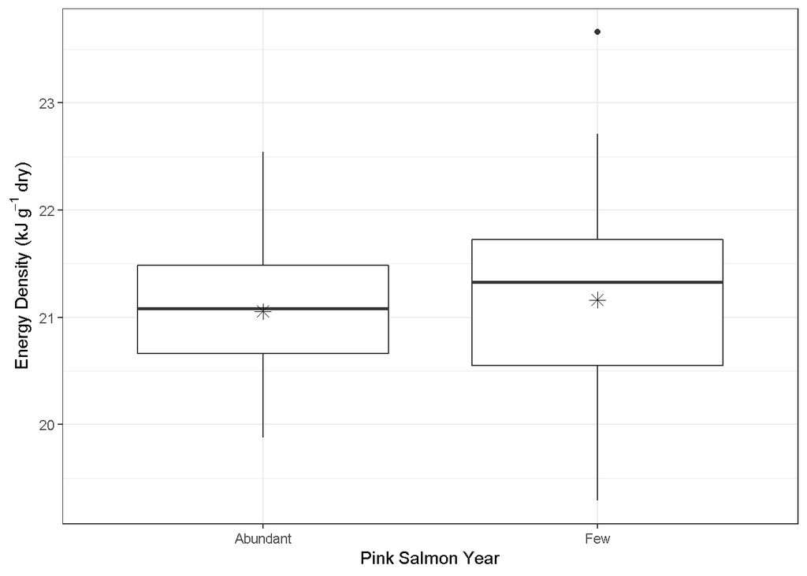

```r
# boxplot
pkbox_bestmodel1 <- ggplot(pkdata,
                           aes(pkDom, ED_1)) +
  geom_boxplot() +
  labs(x = "Pink Salmon Year",
       y = bquote('Energy Density (kJ g'^-1~'dry)')) +
    stat_summary(fun = mean, geom = "point", size = 3, shape = 8)

pkbox_bestmodel1
```

```r
# save plot
ggsave(here::here(OutputFolder, "/pinkEDmeans_bestmodel1.png"),
       width = 3, height = 3)
```

Figure 6. Comparable estimated energy density of Fraser River and East Coast Vancouver Island juvenile sockeye salmon stocks between years with abundant (even) juvenile pink salmon and few (odd) juvenile pink salmon, calculated using the GAM called pdry_fl (Table 1). The box plots display the median (horizontal line within box), first and third quartiles (box top and bottom), range (vertical lines), outliers (circle) and mean (stars) of estimated energy density from abundant and few pink salmon years.

## Appendix

### Summer Energy Density

Appendix Table 1. Summer estimated energy density mean, number of samples (n), minimum (min), maximum (max), standard error (se) and standard deviation (sd) for juvenile sockeye salmon stocks calculated from the GAM called pdry_fl (Table 1). Only stocks with 5 or more individuals are included, and stocks are listed alphabetically.

```r
# select summer and > 5 samples only
stockED_bestmodel1_summer_simp <- stockED_bestmodel1_summer %>%
  filter(n > 4) %>%
  select(-HS_REGION) %>%
  arrange(Stock) %>%
  rename(Region = ORIGIN)

# display table
kable(stockED_bestmodel1_summer_simp) %>%
     kable_styling()
```

| Stock | Region | n | mean | min | max | se | sd |
| --- | --- | --- | --- | --- | --- | --- | --- |
| Birkenhead | Fraser | 17 | 20.40 | 19.47 | 21.42 | 0.14 | 0.58 |
| Chilko | Fraser | 42 | 20.27 | 19.48 | 21.54 | 0.07 | 0.48 |
| Dallery | Rivers & Smith Inlet | 6 | 20.74 | 20.06 | 21.25 | 0.19 | 0.47 |
| Gates Cr | Fraser | 10 | 20.66 | 20.26 | 21.00 | 0.07 | 0.21 |
| Great Central | WCVI | 23 | 20.45 | 19.99 | 21.23 | 0.08 | 0.38 |
| Henderson | WCVI | 5 | 21.14 | 20.28 | 21.89 | 0.27 | 0.61 |
| Kennedy | WCVI | 28 | 20.26 | 19.99 | 20.61 | 0.03 | 0.16 |
| Kuzkwa Cr | Fraser | 23 | 20.38 | 19.73 | 21.24 | 0.07 | 0.33 |
| L Adams | Fraser | 5 | 20.56 | 20.07 | 20.97 | 0.18 | 0.41 |
| L Babine | BC North Coast | 134 | 20.22 | 19.87 | 21.72 | 0.02 | 0.25 |
| Lake Washington | Puget Sound | 21 | 20.54 | 20.05 | 21.00 | 0.07 | 0.32 |
| Little | Fraser | 50 | 20.18 | 19.88 | 20.81 | 0.02 | 0.17 |
| Meziadin | BC North Coast | 23 | 20.29 | 19.94 | 20.92 | 0.04 | 0.21 |
| Mitchell | Fraser | 8 | 20.59 | 20.11 | 21.49 | 0.20 | 0.57 |
| Muchalat | WCVI | 133 | 20.17 | 19.91 | 21.18 | 0.01 | 0.17 |
| Pitt | Fraser | 8 | 20.44 | 19.51 | 21.00 | 0.16 | 0.46 |
| Roaring | Fraser | 6 | 20.02 | 19.88 | 20.18 | 0.04 | 0.10 |
| Rocky Reach | Columbia | 6 | 20.27 | 20.09 | 20.45 | 0.06 | 0.15 |
| Sproat | WCVI | 17 | 20.36 | 19.93 | 20.86 | 0.08 | 0.32 |
| Thompson N | Fraser | 7 | 20.11 | 19.57 | 20.75 | 0.13 | 0.36 |
| Woss Lake | ECVI | 8 | 19.93 | 19.55 | 20.30 | 0.11 | 0.31 |

```r
# write as csv
write_csv(stockED_bestmodel1_summer_simp, here::here(OutputFolder, "/ED_summer_simp.csv"),
          na = "")
```

### Fall Energy Density

Appendix Table 2. Fall estimated energy density mean, number of samples (n), minimum (min), maximum (max), standard error (se) and standard deviation (sd) for juvenile sockeye salmon stocks calculated from the GAM called pdry_fl (Table 1). Only stocks with 5 or more individuals are included, and stocks are listed alphabetically.

```r
# fall and at least 5 samples
stockED_bestmodel1_fall_simp <- stockED_bestmodel1_fall %>%
  filter(n > 4) %>%
  select(-HS_REGION) %>%
  # fix truncated stocks
  mutate(Stock = case_when(
    Stock == "Middleshuswap" ~ "Middle Shuswap",
    Stock == "Quesnel Horsef" ~ "Quesnel Horsefly",
    Stock == "Quesnel Mitche" ~ "Quesnel Mitchell",
    TRUE ~ Stock
  )) %>%
  arrange(Stock) %>%
  rename(Region = ORIGIN)

# display table
kable(stockED_bestmodel1_fall_simp) %>%
     kable_styling()
```

| Stock | Region | n | mean | min | max | se | sd |
| --- | --- | --- | --- | --- | --- | --- | --- |
| Amback | Rivers & Smith Inlet | 23 | 21.18 | 20.68 | 21.82 | 0.07 | 0.33 |
| Bella Coola Mix | BC Central Coast | 6 | 20.95 | 20.34 | 21.94 | 0.25 | 0.62 |
| Birkenhead | Fraser | 18 | 21.42 | 20.94 | 22.22 | 0.08 | 0.33 |
| Bugleg Cr Rt | BC North Coast | 77 | 21.76 | 20.28 | 22.73 | 0.06 | 0.55 |
| Chilko | Fraser | 130 | 21.48 | 19.41 | 22.42 | 0.04 | 0.50 |
| Dallery | Rivers & Smith Inlet | 49 | 21.63 | 20.50 | 22.96 | 0.07 | 0.52 |
| Gingit Rt | BC North Coast | 63 | 20.96 | 20.31 | 22.24 | 0.06 | 0.45 |
| Glendale | BC South Coast | 5 | 21.44 | 21.02 | 22.00 | 0.19 | 0.43 |
| Great Central | WCVI | 57 | 21.43 | 20.42 | 22.51 | 0.07 | 0.53 |
| Harrison | Fraser | 62 | 20.31 | 19.92 | 21.27 | 0.04 | 0.29 |
| Henderson | WCVI | 6 | 21.51 | 21.00 | 22.37 | 0.21 | 0.51 |
| Kennedy | WCVI | 10 | 21.00 | 20.39 | 21.58 | 0.13 | 0.40 |
| Kimsquit | BC Central Coast | 5 | 21.40 | 20.76 | 21.84 | 0.18 | 0.40 |
| Kitimat | BC Central Coast | 16 | 21.00 | 20.50 | 21.76 | 0.09 | 0.35 |
| Kitkiata Lake | BC Central Coast | 22 | 21.71 | 20.88 | 22.44 | 0.11 | 0.49 |
| Kitlope | BC Central Coast | 48 | 21.13 | 19.93 | 22.43 | 0.08 | 0.55 |
| L Adams | Fraser | 122 | 21.30 | 20.69 | 22.37 | 0.03 | 0.38 |
| L Shuswap | Fraser | 40 | 21.15 | 20.50 | 22.15 | 0.06 | 0.40 |
| Little | Fraser | 67 | 21.60 | 19.96 | 23.66 | 0.08 | 0.65 |
| Long Lake | Rivers & Smith Inlet | 26 | 21.08 | 20.26 | 22.31 | 0.10 | 0.51 |
| M Horsefly | Fraser | 5 | 21.48 | 20.93 | 22.11 | 0.24 | 0.54 |
| McDonald | SEAK | 8 | 21.29 | 20.68 | 21.67 | 0.14 | 0.41 |
| Middle Shuswap | Fraser | 14 | 21.37 | 20.74 | 22.21 | 0.13 | 0.47 |
| Mitchell | Fraser | 18 | 21.73 | 20.70 | 22.34 | 0.11 | 0.46 |
| Neechanz | Rivers & Smith Inlet | 13 | 21.59 | 20.91 | 22.52 | 0.17 | 0.61 |
| Nimpkish L | ECVI | 36 | 20.97 | 20.06 | 22.01 | 0.07 | 0.45 |
| Okanagan | Columbia | 9 | 22.08 | 21.62 | 22.47 | 0.10 | 0.30 |
| Portage Cr | Fraser | 7 | 21.56 | 21.03 | 21.97 | 0.12 | 0.33 |
| Quesnel Horsefly | Fraser | 7 | 21.69 | 21.23 | 22.38 | 0.16 | 0.42 |
| Quesnel Mitchell | Fraser | 7 | 21.30 | 20.82 | 21.91 | 0.15 | 0.39 |
| Scotch | Fraser | 39 | 21.31 | 20.40 | 22.46 | 0.08 | 0.53 |
| Seymour | Fraser | 30 | 21.36 | 20.67 | 22.52 | 0.10 | 0.52 |
| Sheemahant | Rivers & Smith Inlet | 5 | 20.95 | 20.36 | 21.36 | 0.16 | 0.36 |
| Sproat | WCVI | 7 | 21.35 | 20.68 | 21.94 | 0.16 | 0.41 |
| Stellako | Fraser | 5 | 21.30 | 20.59 | 22.71 | 0.37 | 0.82 |
| Vernon L | WCVI | 5 | 21.27 | 20.49 | 22.28 | 0.31 | 0.69 |
| Washwash | Rivers & Smith Inlet | 16 | 21.22 | 20.65 | 22.49 | 0.13 | 0.51 |
| Weaver | Fraser | 5 | 21.45 | 20.85 | 22.43 | 0.30 | 0.66 |
| Woss Lake | ECVI | 40 | 21.14 | 20.04 | 22.07 | 0.09 | 0.57 |

```r
# write as csv
write_csv(stockED_bestmodel1_fall_simp, here::here(OutputFolder, "/ED_fall_simp.csv"),
          na = "")
```

## Supplemental Information

An [RMarkdown file](https://github.com/ErikaDAnderson/SockeyeEnergyDensityPub/blob/main/RMarkdown/SockeyeEnergyDensity_GAM.Rmd) is available on Github for code underlying the models, tables and figures.

```r
# modelled calorimetry data
supp_data <- dry_gsi_mod %>%
  select(CRUISE, DATE, MONTH, LAT, LONG, FISH_NUMBER, PDRY, FORK, ED, STOCK, ORIGIN, bestmodel1, gam_stk, ED_1) %>%
  # change list to numeric for model columns
  mutate(bestmodel1 = as.numeric(bestmodel1),
         gam_stk = as.numeric(gam_stk),
         ED_1 = as.numeric(ED_1)) %>%
  rename(FinalED = ED_1) %>%
  arrange(DATE, FISH_NUMBER)

# save data as csv file
write_csv(supp_data, here::here(OutputFolder, "/supp_data.csv"), na = "")
```

### Surveys

Supplementary Table 1. Survey details for juvenile sockeye salmon collections from 1998 to 2020. Tows are the number of tows per survey. GSI refers to genetic stock identification of juvenile sockeye samples that have been identified to stock with a probability of > 0.5, with fork length and percent dry weight values. ED are the number of samples with measured energy density using a calorimeter, and used in the training dataset for the model. No dry weights were completed from 2013-2017 surveys.

```r
kable(cruisesTable) %>%
  kable_styling()
```

| CRUISE | START_DATE | END_DATE | VESSEL | TOWS | GSI | ED |
| --- | --- | --- | --- | --- | --- | --- |
| 9816 | 1998-06-02 | 1998-06-18 | CCGS W.E. RICKER | 25 | 132 |  |
| 9817 | 1998-07-16 | 1998-07-25 | CCGS W.E. RICKER | 49 | 35 |  |
| 9818 | 1998-08-25 | 1998-09-03 | CCGS W.E. RICKER | 30 | 4 |  |
| 9913 | 1999-05-17 | 1999-05-30 | CCGS W.E. RICKER | 59 | 37 |  |
| 9914 | 1999-06-18 | 1999-06-26 | CCGS W.E. RICKER | 43 | 97 |  |
| 200016 | 2000-06-27 | 2000-07-06 | CCGS W.E. RICKER | 43 | 185 |  |
| 200034 | 2000-10-04 | 2000-10-30 | CCGS W.E. RICKER | 127 | 103 |  |
| 200114 | 2001-06-14 | 2001-06-24 | CCGS W.E. RICKER | 70 | 17 |  |
| 200118 | 2001-07-28 | 2001-08-18 | CCGS W.E. RICKER | 94 | 42 |  |
| 200136 | 2001-10-09 | 2001-11-05 | CCGS W.E. RICKER | 147 | 93 |  |
| 200215 | 2002-06-16 | 2002-06-28 | CFV OCEAN SELECTOR | 69 | 5 |  |
| 200235 | 2002-08-15 | 2002-08-26 | CCGS W.E. RICKER | 63 | 24 |  |
| 200238 | 2002-10-17 | 2002-11-09 | CCGS W.E. RICKER | 122 | 23 | 36 |
| 200304 | 2003-02-14 | 2003-02-26 | CCGS W.E. RICKER | 75 | 20 | 39 |
| 200316 | 2003-08-27 | 2003-08-27 | CCGS W.E. RICKER | 5 | 13 |  |
| 200336 | 2003-10-08 | 2003-10-27 | CCGS W.E. RICKER | 95 | 68 |  |
| 200403 | 2004-02-13 | 2004-02-28 | CCGS W.E. RICKER | 63 | 8 |  |
| 200432 | 2004-10-20 | 2004-11-21 | CCGS W.E. RICKER | 126 | 130 |  |
| 200503 | 2005-03-04 | 2005-03-25 | CCGS W.E. RICKER | 124 | 9 |  |
| 200528 | 2005-10-27 | 2005-11-20 | CFV FROSTI | 130 | 34 |  |
| 200609 | 2006-02-28 | 2006-03-27 | CCGS W.E. RICKER | 132 | 4 |  |
| 200631 | 2006-11-07 | 2006-12-05 | CCGS W.E. RICKER | 117 | 14 |  |
| 200765 | 2007-10-10 | 2007-11-03 | CFV VIKING STORM | 158 | 24 |  |
| 200812 | 2008-03-01 | 2008-03-22 | CFV VIKING STORM AND CCGS W.E. RICKER | 148 | 35 |  |
| 200815 | 2008-10-07 | 2008-11-13 | CCGS W.E. RICKER | 158 | 312 |  |
| 200901 | 2009-02-24 | 2009-03-22 | CCGS W.E. RICKER | 145 | 9 |  |
| 200946 | 2009-10-08 | 2009-11-16 | CCGS W.E. RICKER | 134 | 241 |  |
| 201003 | 2010-02-05 | 2010-03-15 | CCGS W.E. RICKER | 205 | 32 |  |
| 201018 | 2010-10-02 | 2010-11-19 | CCGS W.E. RICKER | 171 | 88 |  |
| 201102 | 2011-02-01 | 2011-02-27 | CCGS W.E. RICKER | 144 | 23 |  |
| 201267 | 2012-10-10 | 2012-11-03 | CCGS W.E. RICKER | 91 | 17 |  |
| 201893 | 2018-06-10 | 2018-06-14 | CFV SEACREST | 30 | 59 | 79 |
| 201873 | 2018-07-05 | 2018-07-29 | CFV SEA CREST | 101 | 6 | 7 |
| 2019124 | 2019-06-15 | 2019-07-15 | CFV NORDIC PEARL | 144 | 32 | 38 |
| 2019125 | 2019-09-30 | 2019-10-09 | CFV SEACREST | 37 | 25 | 30 |
| 2020017 | 2020-10-06 | 2020-10-16 | CCGS SIR JOHN FRANKLIN | 23 | 19 | 28 |

### Scatterplot

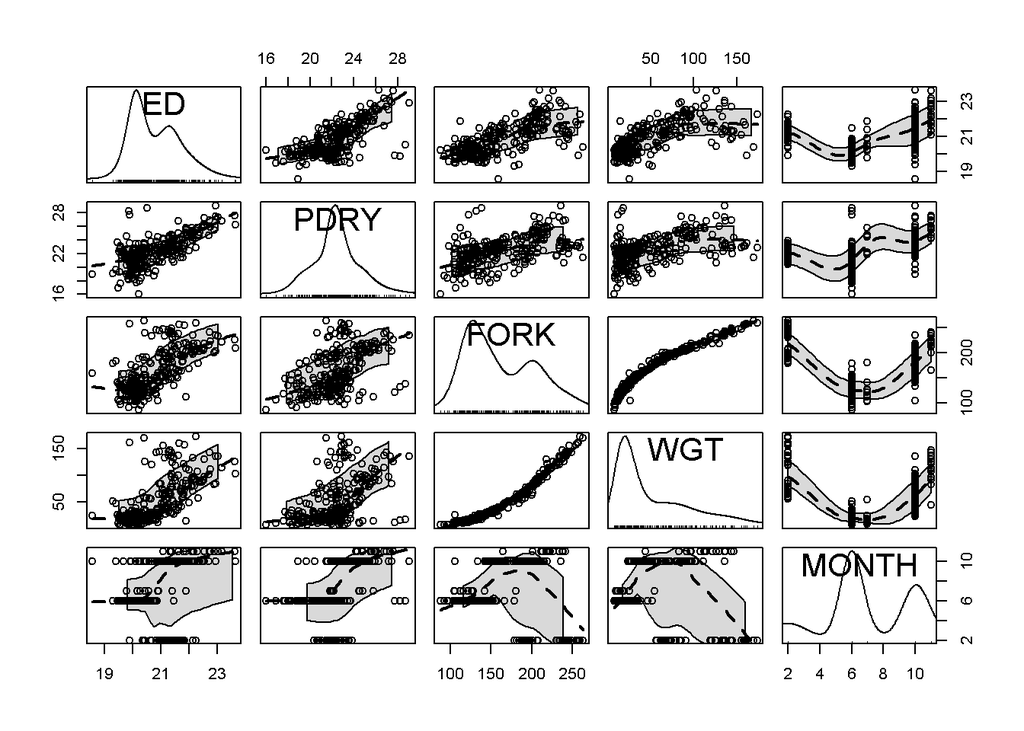

```r
cal_all_month <- cal_all %>%
  mutate(MONTH = case_when(
           MONTH == "2" ~ 2,
           MONTH == "6" ~ 6,
           MONTH == "7" ~ 7,
           MONTH == "10" ~ 10,
           MONTH == "11" ~ 11))

# look at scatter plot matrix to explore which covariates to investigate
# save manually within RStudio to adjust dpi
car::scatterplotMatrix(~ED +PDRY + FORK + WGT + MONTH, cal_all_month,
                       smooth = TRUE,
                       regLine = FALSE,
                       col = "black")
```

Supplementary Figure 1. Relationships between measured energy density (ED, kJ g-1 dry weight), percent dry weight (PDRY), fork length in mm (FORK), wet weight in grams (WGT), and month caught (MONTH). Scatter plot matrix includes 257 juvenile sockeye salmon.

### Diagnostic

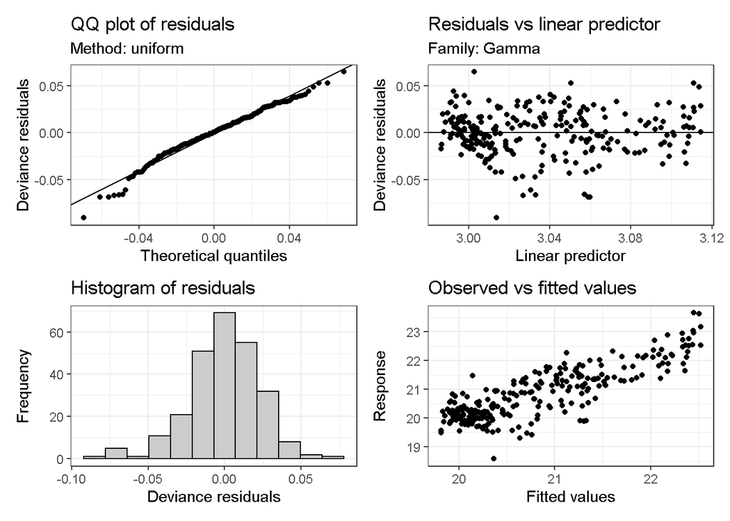

```r
# best model diagnostics
diagnostic_bestmodel1 <- appraise(bestmodel1,
                                  # B&W for journal
                                  line_col = "black")
ggsave(here::here(str_c(OutputFolder,
                        "/diagnostic_bestmodel1.png")),
       diagnostic_bestmodel1)
diagnostic_bestmodel1
```

Supplementary Figure 2. Diagnostic plots for GAM called pdry_fl (Table 1), indicate normality assumption is reasonable, and there are no discernible residual trends. There are leverage points at the lower extreme of the model, so care must be taken at the lower limits of the model.